# COGS 108 - Final Project

# Overview

In this project, we are going to examine the relationship between the trendiness on the Google search engine of 3 Democratic 2020 Presidential candidates and their fundraising results from the start of the announcements of each of their candidacies to the end of March (limit of Federal Electoral Committee data). For fundraising results of each candidate, we focus on three columns: total contributions raised, number of unique donors, and total contribution amount for each US Division (defined by the US Census Bureau). By analyzing the trendiness of candidates on Google to fundraising results, we endeavor to explore the relationship between one's digital popularity and his/her success in fundraising during the same period of time (if a relationship exists at all).

# Names

- Kartik Bhatnagar
- Kai-Chin Shih
- Sahana Srinivasan
- (Isaac) Fangzheng Xie
- (Gin) Xiaojin Zheng

# Group Members IDs

- A14020665
- A12879790
- A13741839
- A13768347
- A15674894

# Research Questions

### Main question: Are candidates' trendiness on search engines, particularly Google, correlated with fundraising results？

1. Is there a correlation between a candidate’s trendiness on Google on each day following the announcement of his or her candidacy and the total contribution amount on each day to the candidate?
2. Is there a correlation between a candidate’s trendiness on Google on each day following the announcmet of his candidacy and the total number of unique donors a candidate receives on each day?
3. Is there a correlation between a candidate's trendiness on Google and the total contribution amount in each U.S. Census Bureau Region and Division for each candidate?

## Background and Prior Work

The race to become the Democratic Party's frontrunner to take on Trump in 2020 has already begun. More than 25 Democrats have already kicked off their presidential campaigns and begun fundraising. In recent years, campaign funds available to candidates have increasingly determined the way elections pan out. Higher campaign contributions (and unique donors) indicate greater visibility, more rallies, and more opportunties for outreach for candidates, and it can subsquently often be the difference between a win and a loss. In fact, according to the Huffington Post [1], the number of unique donors a candidate has will determine who qualifies for the primary debates in 2020, with a requirement of 65,000 unique donors being placed on the qualification. Clearly, this matter is highly relevant.

Social media and online visibility have also played an increasingly important role in a candidate's outreach and momentum. In recent elections, it has completely changed the way candidates interact with their audiences, attract volunteers, and (importantly) gain campaign contributions. Also, with more and more candidates rejecting Super Pac contributions and large donations by corporations, campaign donations by actual voters on a small scale are becoming pivotal to the effectiveness of a candidate's campaign. The volume and distributions of these donations can potentially provide interesting insights into a candidate's viability because it, in a sense, reflects the enthusiasm for the campaign.

Some contend that the correlation between popularity in social media and political fundraising is virtually non-existent. In "In the 2020 Race, What is the Value of Political Stardom?," Issie Lapowsky addresses the fact that Pete Buttigieg's widespread popularity on social media has not been reflected in the amount of money his campaign has secured [2]. In this project, we attempt to more closely examine the relationship between online visibility and interest in a candidate, and the campaign contributions recieved by them. We hope to explore how a candidate's Google search trends relate to the amount of funds raised by them, the number of unique donors they secure, and the geoographical relationships between their online visibilty and donation rates.

[1] https://www.huffpost.com/entry/democratic-candidates-qualified-debates_n_5cd1c531e4b0e4d757394178

[2] https://www.wired.com/story/2020-race-democrats-social-media-stardom/

# Hypothesis

Our hypothesis is that the total contributions, total number of unique donors, and total contribution amount by each census region will increase as the candidates’ trendiness rises. In other words, we believe that the correlation between donorship and trendiness is positive. But, we are not claiming that there is causation, or that a candidate's trendiness on Google causes an increase in donations, or vice versa. However, we are asserting that there is an association between the two.

1.) H0 (Null Hypothesis): There is no correlation between the total contribution amount and a candidate's trendiness. 2.) H1 (Alternative Hypothesis): As a candidate's trendiness increases, the amount of campaign contributions he or she receives increases. 3.) H0 (Null Hypothesis): There is no correlation between the total number of unique donors a candidate receives and the candidate's trendiness. 4.) H1 (Alternative Hypothesis): As a candidate's trendiness increases, the amount of unique donors he or she has increases. 5.) H0 (Null Hypothesis): There is no correlation between between a candidate's total contribution amount in a given region and his popularity defined by trendiness in the region. 6.) H1 (Alternative Hypothesis): As a candidate's trendiness within a region increases, the total contribution amount in each region increases.

The premise of our assumption is that the more people research a candidate, the more interest there is in a candidate, which could be reflected in increased contribution, as contribution is a prime mechanism for expressing interest.

# Dataset(s)

We selected 3 Democratic candidates, namely Bernie Sanders, Beto O'Rourke, and Kamala Harris, that were the top 3 candidates based on fundraising amounts in a mid-April as declared by a New York Times article titiled "Bernie Sanders and Kamala Harris Lead the Democratic Money Race".

#### 1. Bernie Sanders datasets:

Dataset 1 Name: bernietrend.csv  
Link to the dataset: https://trends.google.com/trends/explore?q=%2Fm%2F01_gbv&geo=US  
Description: Google search trends for Bernie Sanders between date of candidacy declaration and final date of FEC data (Mar 31)  
Variables relevant to project: Date, Trend  
Size: 41 rows and 2 columns  
Dataset 2 Name: bernietrend_state.csv  
Link to the dataset: https://trends.google.com/trends/explore?q=%2Fm%2F01_gbv&geo=US  
Description: Google search trends for Bernie Sanders by state  
Variables relevant to project: State (incl. DC), Trend  
Size: 51 rows and 2 columns  
Dataset 3 Name: FEC_Bernie2020.csv  
Link to the dataset: https://www.fec.gov/data/receipts/individual-contributions/?two_year_transaction_period=2020&committee_id=C00696948&min_date=01%2F01%2F2019&max_date=12%2F31%2F2020  
Description: Individual FEC contribution records for Bernie Sanders  
Variables relevant to project: transaction_id, contribution_receipt_date, contribution_receipt_amount, contributor_state  
Size: 55,805 rows and 77 columns

# Setup

```python
# Display plots directly in the notebook instead of in a new window
%matplotlib inline

# Import libraries
import numpy as np
import pandas as pd
import matplotlib.pyplot as plt
import seaborn as sns
import geopandas as gpd

from shapely.geometry import Point, Polygon

import matplotlib.pyplot as plt
plt.rcParams['figure.figsize'] = (17, 5)
plt.rcParams.update({'font.size': 16})
from mpl_toolkits.axes_grid1 import make_axes_locatable

%matplotlib inline

import shapely.geometry as shp

import sklearn.neighbors as skn
import sklearn.metrics as skm

pd.options.display.max_rows = 10

import patsy
import statsmodels.api as sm
import scipy.stats as stats
from scipy.stats import ttest_ind, chisquare, normaltest

#improve resolution
#comment this line if erroring on your machine/screen
%config InlineBackend.figure_format ='retina'
```

```python
# Configure libraries
# The seaborn library makes plots look nicer
sns.set()
sns.set_context('talk')

# Don't display too many rows/cols of DataFrames
pd.options.display.max_rows = 10
pd.options.display.max_columns = 8

# Round decimals when displaying DataFrames
pd.set_option('precision', 2)
```

# Data Cleaning & Exploration

### I. To check candidates popularity through Google searches through time

```python
#Bernie Sanders
# Load Google Trends csv file as dataframe
dfBSTrend = pd.read_csv('bernietrend.csv')
# Set column names
dfBSTrend.columns = ['date','trend']
# Change data type from strings to number and date
dfBSTrend['trend'] = dfBSTrend['trend'].apply(pd.to_numeric, errors = 'coerce')
dfBSTrend['date'] = dfBSTrend['date'].astype('datetime64')

#Beto O'Rourke
# Load Google Trends csv file as dataframe
dfBOTrend = pd.read_csv('betotrend.csv')
# Set column names
dfBOTrend.columns = ['date','trend']
# Change data type from strings to number and date
dfBOTrend['trend'] = dfBOTrend['trend'].apply(pd.to_numeric, errors = 'coerce')
dfBOTrend['date'] = dfBOTrend['date'].astype('datetime64')

# Kamala Harris
# Load Google Trends csv file as dataframe
dfKHTrend = pd.read_csv('kamalatrend.csv')
# Set column names
dfKHTrend.columns = ['date','trend']
# Change data type from strings to number and date
dfKHTrend['trend'] = dfKHTrend['trend'].apply(pd.to_numeric, errors = 'coerce')
dfKHTrend['date'] = dfKHTrend['date'].astype('datetime64')
```

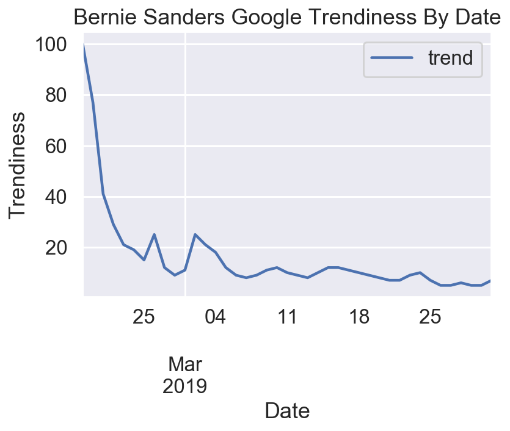

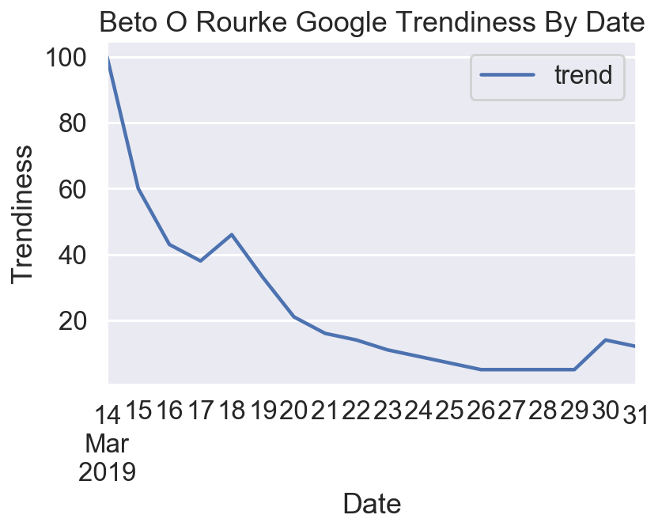

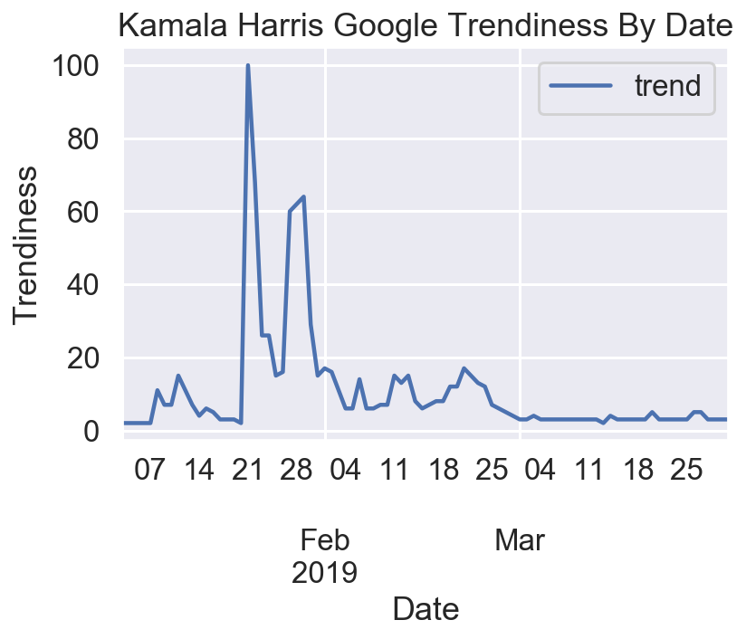

```python
#Bernie Sanders
#Plot the trend and add appropriate axis labels
bernie = dfBSTrend.plot(x='date', y='trend')
bernie.set_xlabel('Date')
bernie.set_ylabel('Trendiness')
bernie.set_title('Bernie Sanders Google Trendiness By Date')

#Beto O'Rourke
#Plot the trend and add appropriate axis labels
beto = dfBOTrend.plot(x = 'date', y = 'trend')
beto.set_xlabel('Date')
beto.set_ylabel('Trendiness')
beto.set_title('Beto O Rourke Google Trendiness By Date')

# Kamala Harris
#Plot the trend and add appropriate axis labels
kamala = dfKHTrend.plot(x = 'date', y = 'trend')
kamala.set_xlabel('Date')
kamala.set_ylabel('Trendiness')
kamala.set_title('Kamala Harris Google Trendiness By Date')
```

Data Processing Explanation:

To clean the data we obtained from Google Trends, we first defined the columns to be 'date' and 'trend' so we could effectively plot them against each other. We then changed the format of the date and trend columns to variable types that were compatible for our analysis.

The graphs above describe the trendiness of each candidate from the time they announced their candidacies to the final date through which FEC data on each candidate is available. Though each candidate's graph has a different starting point, the FEC data for all candidates ends at the end of March. As the graphs demonstrate, candidates appear to peak in popularity at (or near) the beginning of their entrance into the race. Then, their popularity seems to level off. There are some exceptions to this trend, however. These surges in popularity are likely attributable to major political events that a candidate involved him or herself in.

### II. To check total donation volume to candidates through FEC data by time trend

```python
#Bernie Sanders
#Load FEC campaign contribution file as dataframe
dfBSFEC = pd.read_csv('FEC_Bernie2020.csv')
# Set column names
dfBSFEC = dfBSFEC[['transaction_id', 'contribution_receipt_date', 'contribution_receipt_amount', 'contributor_state']]
# Change data type from string to date or numeric form
dfBSFEC['contribution_receipt_date'] = dfBSFEC['contribution_receipt_date'].astype("datetime64")
dfBSFEC['contribution_receipt_amount'] = dfBSFEC['contribution_receipt_amount'].apply(pd.to_numeric)

#Beto O'Rourke
#Load FEC campaign contribution file as dataframe
dfBOFEC = pd.read_csv('FEC_Beto2020.csv')
# Set column names
dfBOFEC = dfBOFEC[['transaction_id', 'contribution_receipt_date', 'contribution_receipt_amount', 'contributor_state']]
# Change data type from string to date or numeric form
dfBOFEC['contribution_receipt_date'] = dfBOFEC['contribution_receipt_date'].astype("datetime64")
dfBOFEC['contribution_receipt_amount'] = dfBOFEC['contribution_receipt_amount'].apply(pd.to_numeric)

#Kamala Harris
#Load FEC campaign contribution file as dataframe
dfKHFEC = pd.read_csv('FEC_Kamala2020.csv')
# Set column names
dfKHFEC = dfKHFEC[['transaction_id', 'contribution_receipt_date', 'contribution_receipt_amount', 'contributor_state']]
# Change data type from string to date or numeric form
dfKHFEC['contribution_receipt_date'] = dfKHFEC['contribution_receipt_date'].astype("datetime64")
dfKHFEC['contribution_receipt_amount'] = dfKHFEC['contribution_receipt_amount'].apply(pd.to_numeric)
```

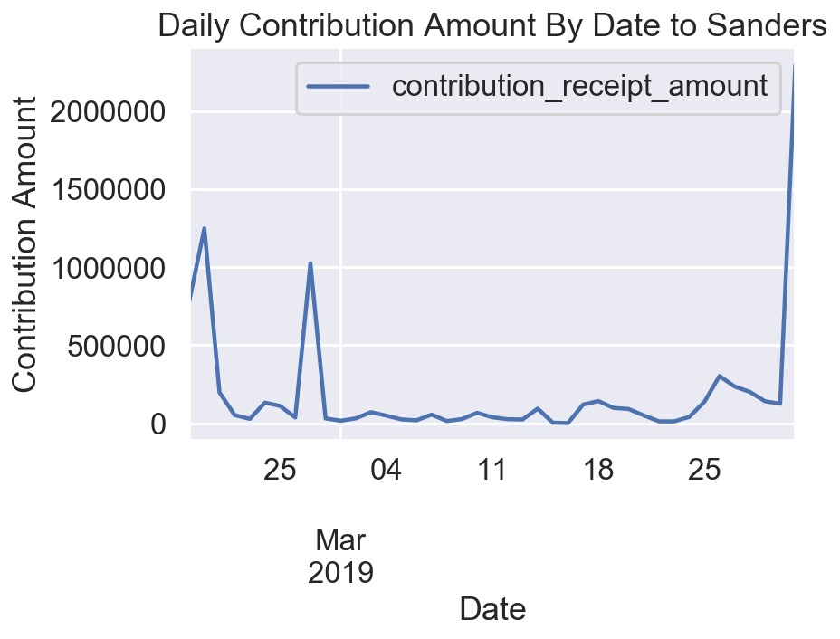

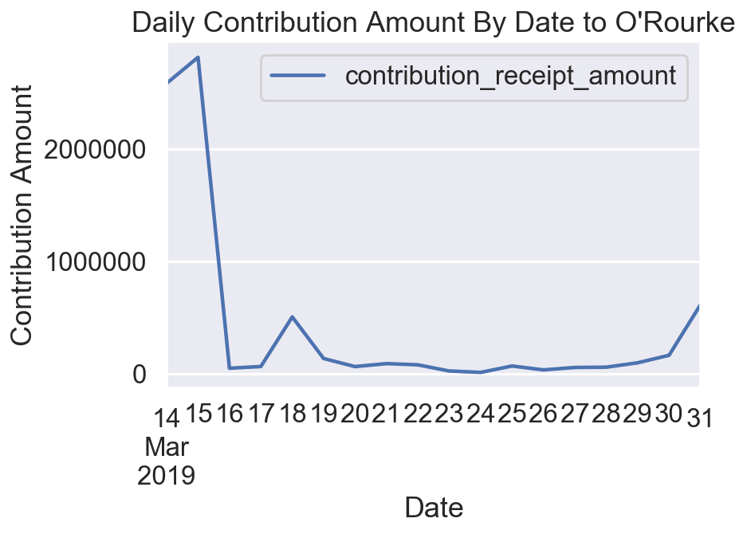

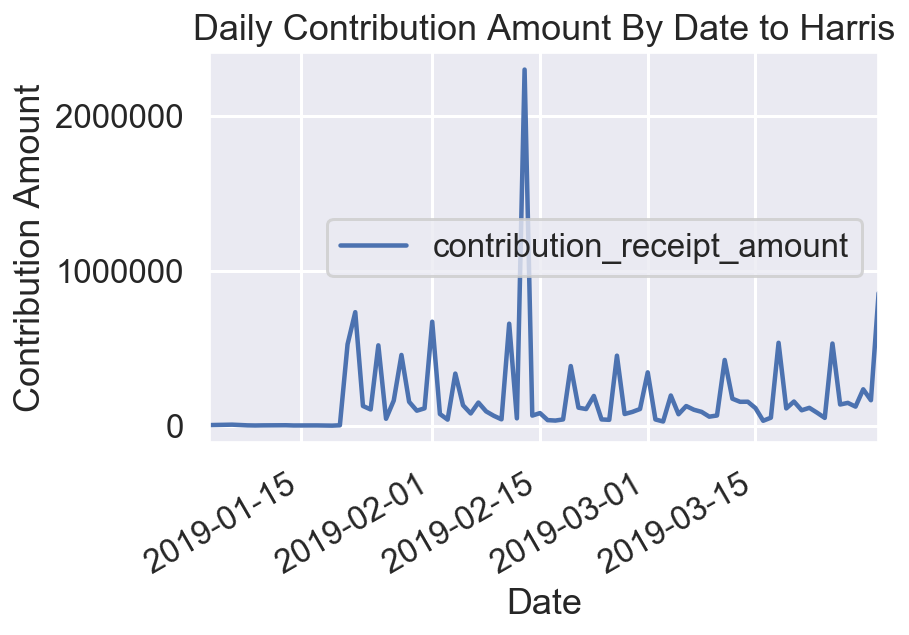

```python
# Bernie Sanders
# Create pivot table to obtain total amount raised for each day
dfBSAmount = pd.pivot_table(dfBSFEC, index=['contribution_receipt_date'],values=["contribution_receipt_amount"],aggfunc=np.sum)
# Set column name as date
dfBSAmount.index.names = ['date']
# Plot Bernie daily contribution amounts
bernie2 = dfBSAmount.plot()
# Set graph appearance
bernie2.set_xlabel('Date')
bernie2.set_ylabel('Contribution Amount')
bernie2.set_title('Daily Contribution Amount By Date to Sanders')

# Beto O'Rourke
# Create pivot table to obtain total amount raised for each day
dfBOAmount = pd.pivot_table(dfBOFEC, index = ['contribution_receipt_date'], values = ["contribution_receipt_amount"], aggfunc = np.sum)
# Set column name as date
dfBOAmount.index.names = ['date']
# Plot Beto daily contribution amounts
beto2 = dfBOAmount.plot()
# Set graph appearance
beto2.set_xlabel('Date')
beto2.set_ylabel('Contribution Amount')
beto2.set_title('Daily Contribution Amount By Date to O\'Rourke')

# Kamala Harris
# Create pivot table to obtain total amount raised for each day
dfKHAmount = pd.pivot_table(dfKHFEC, index = ['contribution_receipt_date'], values = ["contribution_receipt_amount"],aggfunc=np.sum)
# Set column name as date
dfKHAmount.index.names = ['date']
# Plot Kamala daily contribution amounts
kamala2 = dfKHAmount.plot()
# Set graph appearance
kamala2.set_xlabel('Date')
kamala2.set_ylabel('Contribution Amount')
kamala2.set_title('Daily Contribution Amount By Date to Harris')
```

Data Processing Explanation:

We used a similar mechanism to process and clean the Federal Election Commission Data. We converted both 'date' and 'contributuion amount' to variable types that we could effectively graph.

The graphs above depict the total amount of contribution to a given candidate from the start of the announcment of their candidacy to the end of March. Each candidate's contribution amount seems to peak at different times; the trend is not as consistent across candidates as it was for the trendiness data. We theorize that surges in popularity are associated with pivotal moments associated with either a candidate's campaign or their political standing that capture the attention of their voting base. While Sanders and O'Rourke experience a surge in funding at the beginning of their campaigns, Harris received a surge nearly a month after, one that was likely a byproduct of her political campaigning and townhalls.

### III. To check total daily unique donation counts to candidates through FEC data by time trend

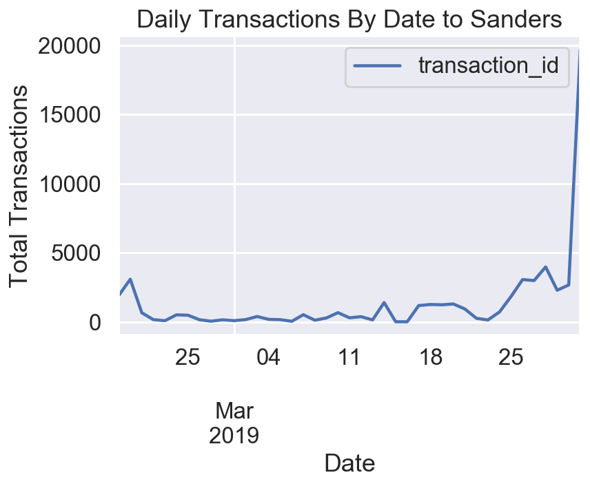

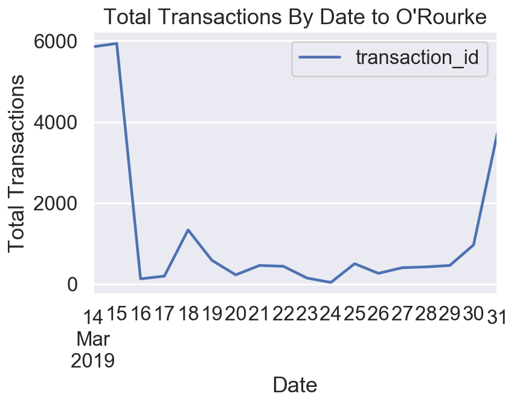

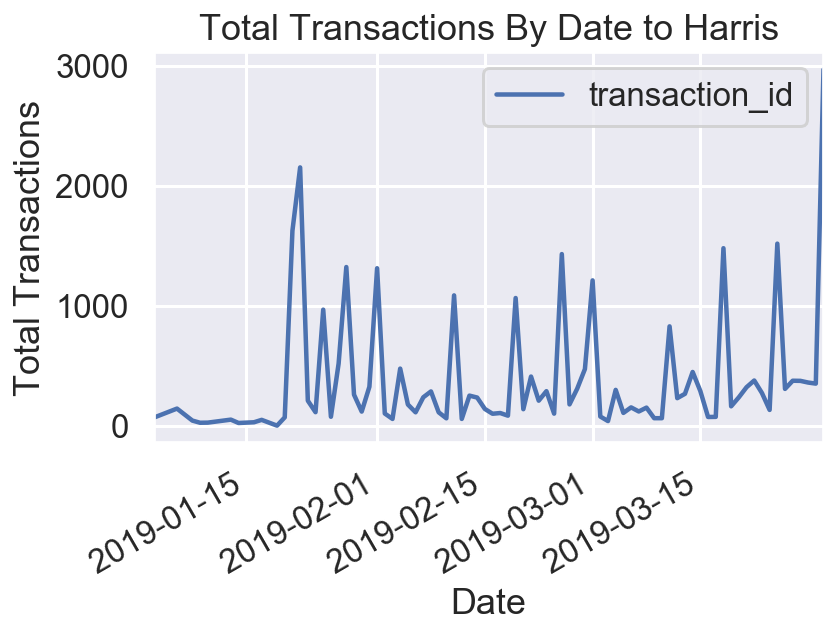

```python
# Bernie Sanders
# Create pivot table to obtain total number of transactions each day
dfBSDonors = pd.pivot_table(dfBSFEC, index=["contribution_receipt_date"],values=["transaction_id"], aggfunc=lambda x: len(x.unique()))
# Set column name
dfBSDonors.index.names = ['date']
# Plot total number of transactions
bernie3 = dfBSDonors.plot()
# Set graph appearance
bernie3.set_xlabel('Date')
bernie3.set_ylabel('Total Transactions')
bernie3.set_title('Daily Transactions By Date to Sanders')

# Beto O'Rourke
# Create pivot table to obtain total number of transactions each day
dfBODonors = pd.pivot_table(dfBOFEC, index=["contribution_receipt_date"],values=["transaction_id"], aggfunc=lambda x: len(x.unique()))
# Set column name
dfBODonors.index.names = ['date']
# Plot total number of transactions
beto3 = dfBODonors.plot()
# Set graph appearance
beto3.set_xlabel('Date')
beto3.set_ylabel('Total Transactions')
beto3.set_title('Total Transactions By Date to O\'Rourke')

# Kamala Harris
# Create pivot table to obtain total number of transactions each day
dfKHDonors = pd.pivot_table(dfKHFEC, index=["contribution_receipt_date"],values=["transaction_id"], aggfunc=lambda x: len(x.unique()))
# Set column name
dfKHDonors.index.names = ['date']
# Plot total number of transactions
kamala3 = dfKHDonors.plot()
# Set graph appearance
kamala3.set_xlabel('Date')
kamala3.set_ylabel('Total Transactions')
kamala3.set_title('Total Transactions By Date to Harris')
```

The graphs above track the total number of unique donors (or transactions) to a candidate from the same time range used in the previous graphs. There is certainly the least consistency amongst these graphs between each candidate. However, there does appear to be a correlation between the total number of unique donors to the total contribution amount, which suggests that the source of contributions is most likely not a single, dominant donor.

### IV. To check candidates popularity through Google search trend by state

```python
# Bernie Sanders
# Load Google Trends by state file into dataframe
dfBSTrendStates = pd.read_csv('bernietrend_state.csv')
# Set column names
dfBSTrendStates.columns = ['state','trend']
# Change data type to numeric
dfBSTrendStates['trend'] = dfBSTrendStates['trend'].apply(pd.to_numeric, errors = 'coerce')

# Beto O'Rourke
# Load Google Trends by state file into dataframe
dfBOTrendStates = pd.read_csv('betotrend_state.csv')
# Set column names
dfBOTrendStates.columns = ['state','trend']
# Change data type to numeric
dfBOTrendStates['trend'] = dfBOTrendStates['trend'].apply(pd.to_numeric, errors = 'coerce')

# Kamala Harris
# Load Google Trends by state file into dataframe
dfKHTrendStates = pd.read_csv('kamalatrend_state.csv')
# Set column names
dfKHTrendStates.columns = ['state','trend']
# Change data type to numeric
dfKHTrendStates['trend'] = dfKHTrendStates['trend'].apply(pd.to_numeric, errors = 'coerce')
```

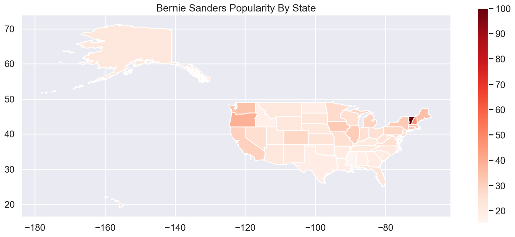

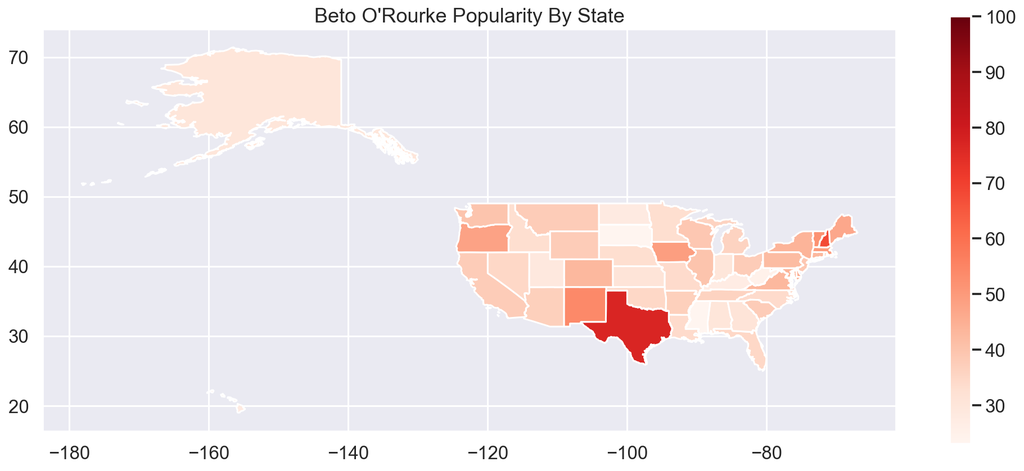

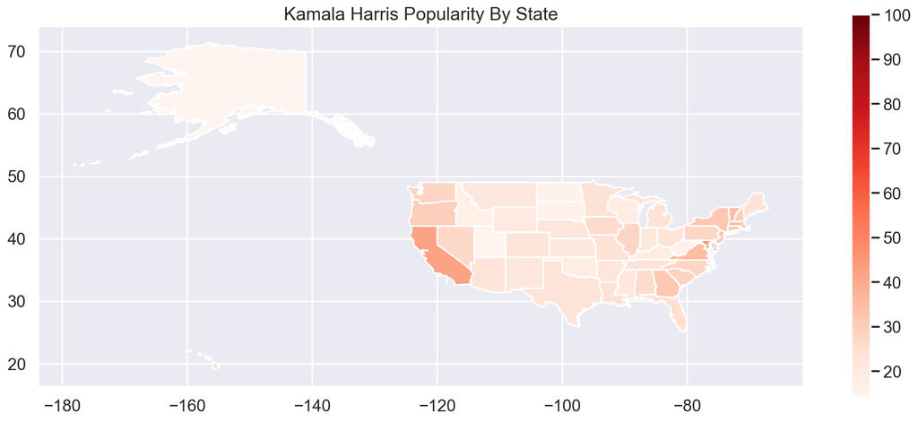

```python
# Loading shape data for mapping
usa = gpd.read_file('./states_21basic/states.shp')
usa = usa.sort_values(by=['STATE_NAME'])

# Bernie Sanders
# Plot Bernie popularity by state onto US map
ig, ax = plt.subplots(1, 1, figsize=(17, 7))
divider = make_axes_locatable(ax)
BSGeo = usa.plot(column=dfBSTrendStates['trend'],ax=ax, cmap='Reds', legend=True);
BSGeo.set_title('Bernie Sanders Popularity By State')

# Beto O'Rourke
# Plot Beto popularity by state onto US map
ig, ax = plt.subplots(1, 1, figsize=(17, 7))
divider = make_axes_locatable(ax)
BOGeo = usa.plot(column=dfBOTrendStates['trend'],ax=ax, cmap='Reds', legend=True);
BOGeo.set_title('Beto O\'Rourke Popularity By State')


# Kamala Harris
# Plot Kamala popularity by state onto US map
ig, ax = plt.subplots(1, 1, figsize=(17, 7))
divider = make_axes_locatable(ax)
KHGeo = usa.plot(column=dfKHTrendStates['trend'],ax=ax, cmap='Reds', legend=True);
KHGeo.set_title('Kamala Harris Popularity By State')
```

### V. Total contribution amount based on U.S. Census Bureau Divisions

```python
# Bernie Sanders
# Create pivot table to obtain total amount raised by state
dfBSStates = pd.pivot_table(dfBSFEC, index=['contributor_state'],values=["contribution_receipt_amount"],aggfunc=np.sum)
# Set column name
dfBSStates.index.names = ['state']

# Beto O'Rourke
# Create pivot table to obtain total amount raised by state
dfBOStates = pd.pivot_table(dfBOFEC, index=['contributor_state'],values=["contribution_receipt_amount"],aggfunc=np.sum)
# Set column name
dfBOStates.index.names = ['state']

# Kamala Harris
# Create pivot table to obtain total amount raised by state
dfKHStates = pd.pivot_table(dfKHFEC, index=['contributor_state'],values=["contribution_receipt_amount"],aggfunc=np.sum)
# Set column name
dfKHStates.index.names = ['state']
```

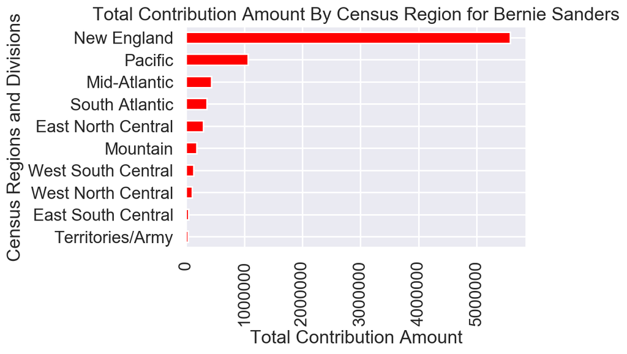

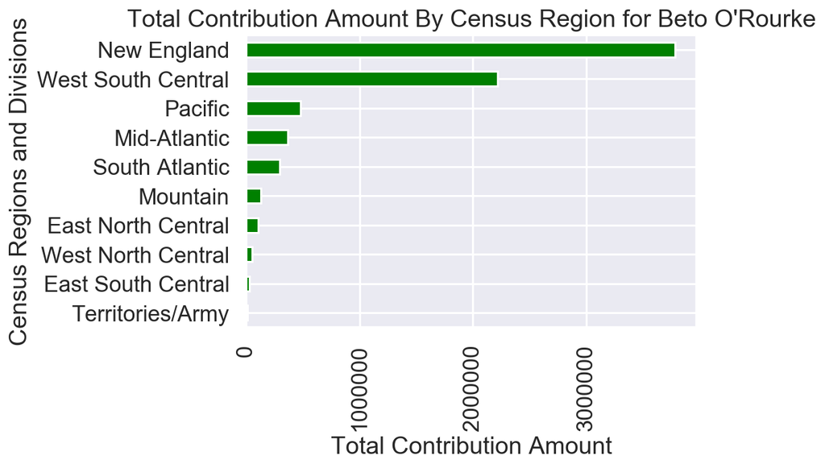

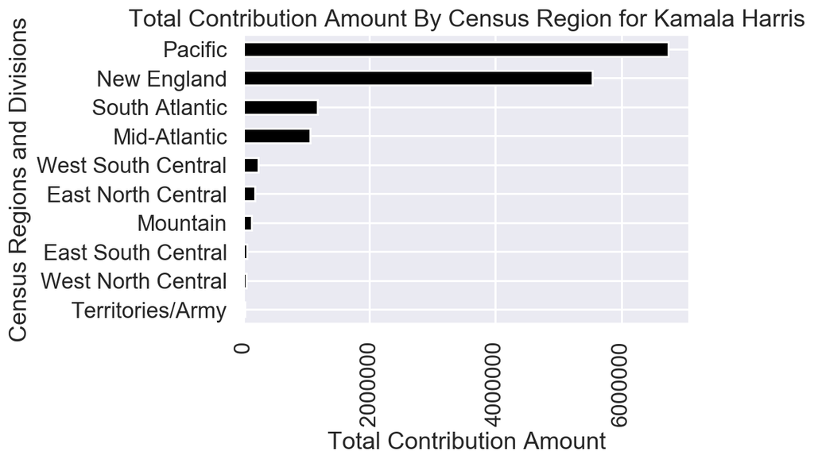

```python
# Census Bureau Division Version
from collections import defaultdict
# Bernie Sanders Fundraising by USCB Division
# Create pivot table to obtain total amount raised by state
# This pivot table is used to aggregate contributions by division
dfBSDivision = pd.pivot_table(dfBSFEC, index=['contributor_state'],values=["contribution_receipt_amount"],aggfunc=np.sum)
# Set column name
dfBSDivision.index.names = ['contributor_state']
dfBSDivision['Division'] = ""
dfBSDivision['Division Total'] = ""

# Dictionary of state abbreviations with division
state2division = {'AA': 'Territories/Army', 'AE': 'Territories/Army', 'AK': 'Pacific', 'AL': 'East South Central', 'AP': 'Territories/Army', 'AR': 'West South Central', 'AS': 'Territories/Army', 'AZ': 'Mountain', 'CA': 'Pacific', 'CO': 'Mountain', 'CT': 'New England', 'DC': 'South Atlantic', 'DE': 'South Atlantic', 'FL': 'South Atlantic', 'GA': 'South Atlantic', 'GU': 'Territories/Army', 'HI': 'Pacific', 'IA': 'West North Central', 'ID': 'Mountain', 'IL': 'East North Central', 'IN': 'East North Central', 'KS': 'West North Central', 'KY': 'East South Central', 'LA': 'West South Central', 'MA': 'New England', 'MD': 'South Atlantic', 'ME': 'New England', 'MI': 'East North Central', 'MN': 'West North Central', 'MO': 'West North Central', 'MP': 'Territories/Army', 'MS': 'East South Central', 'MT': 'Mountain', 'NC': 'South Atlantic', 'ND': 'West North Central', 'NE': 'West North Central', 'NH': 'New England', 'NJ': 'Mid-Atlantic', 'NM': 'Mountain', 'NV': 'Mountain', 'NY': 'Mid-Atlantic', 'OH': 'East North Central', 'OK': 'West South Central', 'OR': 'Pacific', 'PA': 'Mid-Atlantic', 'PR': 'Territories/Army', 'RI': 'New England', 'SC': 'South Atlantic', 'SD': 'West North Central', 'TN': 'East South Central', 'TX': 'West South Central', 'UT': 'Mountain', 'VA': 'South Atlantic', 'VI': 'Territories/Army', 'VT': 'New England', 'WA': 'Pacific', 'WI': 'East North Central', 'WV': 'South Atlantic', 'WY': 'Mountain', 'ZZ': 'Territories/Army'}

# Add division data to original table
for i, row in dfBSDivision.iterrows():
    dfBSDivision.at[i,'Division'] = state2division[i]

# Create pivot table to obtain total amount raised in each region
dfBSDivision_State = pd.pivot_table(dfBSDivision, index=['Division'],values=["contribution_receipt_amount"],aggfunc=np.sum)

# Sort pivot table by funds raised from high to low
dfBSDivision_State = dfBSDivision_State.sort_values(by=['contribution_receipt_amount'])

# Plot ranking of amount raised
f1 = dfBSDivision_State['contribution_receipt_amount'].plot(kind='barh', color = 'red')

plt.plot()
plt.xticks(rotation = 90)

#f1.get_xaxis().setticks([rotation = 90])
f1.set_xlabel('Total Contribution Amount')
f1.set_ylabel('Census Regions and Divisions')
f1.set_title('Total Contribution Amount By Census Region for Bernie Sanders')

plt.show()

#Beto O'Rourke information
dfBODivision = pd.pivot_table(dfBOFEC, index=['contributor_state'],values=["contribution_receipt_amount"],aggfunc=np.sum)
# Set column name
dfBODivision.index.names = ['contributor_state']
dfBODivision['Division'] = ""
dfBODivision['Division Total'] = ""

# Dictionary of state abbreviations with division
state2division = {'AA': 'Territories/Army', 'AE': 'Territories/Army', 'AK': 'Pacific', 'AL': 'East South Central', 'AP': 'Territories/Army', 'AR': 'West South Central', 'AS': 'Territories/Army', 'AZ': 'Mountain', 'CA': 'Pacific', 'CO': 'Mountain', 'CT': 'New England', 'DC': 'South Atlantic', 'DE': 'South Atlantic', 'FL': 'South Atlantic', 'GA': 'South Atlantic', 'GU': 'Territories/Army', 'HI': 'Pacific', 'IA': 'West North Central', 'ID': 'Mountain', 'IL': 'East North Central', 'IN': 'East North Central', 'KS': 'West North Central', 'KY': 'East South Central', 'LA': 'West South Central', 'MA': 'New England', 'MD': 'South Atlantic', 'ME': 'New England', 'MI': 'East North Central', 'MN': 'West North Central', 'MO': 'West North Central', 'MP': 'Territories/Army', 'MS': 'East South Central', 'MT': 'Mountain', 'NC': 'South Atlantic', 'ND': 'West North Central', 'NE': 'West North Central', 'NH': 'New England', 'NJ': 'Mid-Atlantic', 'NM': 'Mountain', 'NV': 'Mountain', 'NY': 'Mid-Atlantic', 'OH': 'East North Central', 'OK': 'West South Central', 'OR': 'Pacific', 'PA': 'Mid-Atlantic', 'PR': 'Territories/Army', 'RI': 'New England', 'SC': 'South Atlantic', 'SD': 'West North Central', 'TN': 'East South Central', 'TX': 'West South Central', 'UT': 'Mountain', 'VA': 'South Atlantic', 'VI': 'Territories/Army', 'VT': 'New England', 'WA': 'Pacific', 'WI': 'East North Central', 'WV': 'South Atlantic', 'WY': 'Mountain', 'ZZ': 'Territories/Army'}

# Add division data to original table
for i, row in dfBODivision.iterrows():
    dfBODivision.at[i,'Division'] = state2division[i]

# Create pivot table to obtain total amount raised in each region
dfBODivision_State = pd.pivot_table(dfBODivision, index=['Division'],values=["contribution_receipt_amount"],aggfunc=np.sum)

# Sort pivot table by funds raised from high to low
dfBODivision_State = dfBODivision_State.sort_values(by=['contribution_receipt_amount'])

# Plot ranking of amount raised
f2 = dfBODivision_State['contribution_receipt_amount'].plot(kind='barh', color = 'green')

plt.plot()
plt.xticks(rotation = 90)

f2.set_xlabel('Total Contribution Amount')
f2.set_ylabel('Census Regions and Divisions')
f2.set_title('Total Contribution Amount By Census Region for Beto O\'Rourke')

plt.show()

dfKHDivision = pd.pivot_table(dfKHFEC, index=['contributor_state'],values=["contribution_receipt_amount"],aggfunc=np.sum)
# Set column name
dfKHDivision.index.names = ['contributor_state']
dfKHDivision['Division'] = ""
dfKHDivision['Division Total'] = ""

# Dictionary of state abbreviations with division
state2division = {'AA': 'Territories/Army', 'AE': 'Territories/Army', 'AK': 'Pacific', 'AL': 'East South Central', 'AP': 'Territories/Army', 'AR': 'West South Central', 'AS': 'Territories/Army', 'AZ': 'Mountain', 'CA': 'Pacific', 'CO': 'Mountain', 'CT': 'New England', 'DC': 'South Atlantic', 'DE': 'South Atlantic', 'FL': 'South Atlantic', 'GA': 'South Atlantic', 'GU': 'Territories/Army', 'HI': 'Pacific', 'IA': 'West North Central', 'ID': 'Mountain', 'IL': 'East North Central', 'IN': 'East North Central', 'KS': 'West North Central', 'KY': 'East South Central', 'LA': 'West South Central', 'MA': 'New England', 'MD': 'South Atlantic', 'ME': 'New England', 'MI': 'East North Central', 'MN': 'West North Central', 'MO': 'West North Central', 'MP': 'Territories/Army', 'MS': 'East South Central', 'MT': 'Mountain', 'NC': 'South Atlantic', 'ND': 'West North Central', 'NE': 'West North Central', 'NH': 'New England', 'NJ': 'Mid-Atlantic', 'NM': 'Mountain', 'NV': 'Mountain', 'NY': 'Mid-Atlantic', 'OH': 'East North Central', 'OK': 'West South Central', 'OR': 'Pacific', 'PA': 'Mid-Atlantic', 'PR': 'Territories/Army', 'RI': 'New England', 'SC': 'South Atlantic', 'SD': 'West North Central', 'TN': 'East South Central', 'TX': 'West South Central', 'UT': 'Mountain', 'VA': 'South Atlantic', 'VI': 'Territories/Army', 'VT': 'New England', 'WA': 'Pacific', 'WI': 'East North Central', 'WV': 'South Atlantic', 'WY': 'Mountain', 'ZZ': 'Territories/Army'}

# Add division data to original table
for i, row in dfBODivision.iterrows():
    dfKHDivision.at[i,'Division'] = state2division[i]

# Create pivot table to obtain total amount raised in each region
dfKHDivision_State = pd.pivot_table(dfKHDivision, index=['Division'],values=["contribution_receipt_amount"],aggfunc=np.sum)

# Sort pivot table by funds raised from high to low
dfKHDivision_State = dfKHDivision_State.sort_values(by=['contribution_receipt_amount'])

# Plot ranking of amount raised
f3 = dfKHDivision_State['contribution_receipt_amount'].plot(kind='barh', color = 'black')

plt.plot()
plt.xticks(rotation = 90)

f3.set_xlabel('Total Contribution Amount')
f3.set_ylabel('Census Regions and Divisions')
f3.set_title('Total Contribution Amount By Census Region for Kamala Harris')

plt.show()

#f1.get_xaxis().setticks([rotation = 90])
#f2.set_xlabel('Total Contribution Amount')
#f2.set_ylabel('Census Regions and Divisions')
#f2.set_title('Total Contribution Amount By Census Region for Beto O\Rourke')
```

The graphs above demonstrate the amount of total contributions from unique donors for each census region and division for each candidate. Census divisions are based off of relevant economic and geographic factors. The divisions are as follows:  
Division 1: New England (Connecticut, Maine, Massachusetts, New Hampshire, Rhode Island, and Vermont)  
Division 2: Mid-Atlantic (New Jersey, New York, and Pennsylvania)  
Division 3: East North Central (Illinois, Indiana, Michigan, Ohio, and Wisconsin)  
Division 4: West North Central (Iowa, Kansas, Minnesota, Missouri, Nebraska, North Dakota, and South Dakota)  
Division 5: South Atlantic (Delaware, Florida, Georgia, Maryland, North Carolina, South Carolina, Virginia, District of Columbia, and West Virginia)  
Division 6: East South Central (Alabama, Kentucky, Mississippi, and Tennessee)  
Division 7: West South Central (Arkansas, Louisiana, Oklahoma, and Texas)  
Division 8: Mountain (Arizona, Colorado, Idaho, Montana, Nevada, New Mexico, Utah, and Wyoming)  
Division 9: Pacific (Alaska, California, Hawaii, Oregon, and Washington)  
Bernie Sanders and Beto O'Rourke exhibit clear edges in the New England division. Although this makes sense for Sanders as he is from Vermont, this makes less sense for O'Rourke as he is from Texas. Harris finds greatest contribution from the Pacific division, which makes sense because of her presence as a Senator in California. While Sanders' 2nd most popular division is the Pacific region, Harris' is the New England region. O'Rourke, interestingly, is 2nd most popular in the West South Central region, which contains the state from which he is a representative, Texas. Thus, these graphs provide a wealth of information regarding campaign donorship.

Below, we will be exploring the same data in map form.

```
No handles with labels found to put in legend.
No handles with labels found to put in legend.
No handles with labels found to put in legend.
```

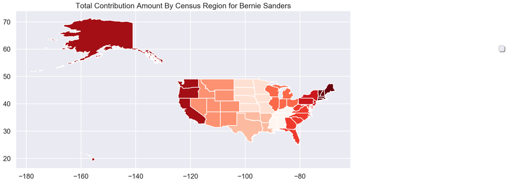

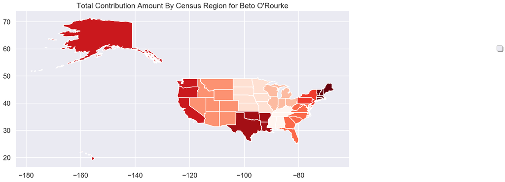

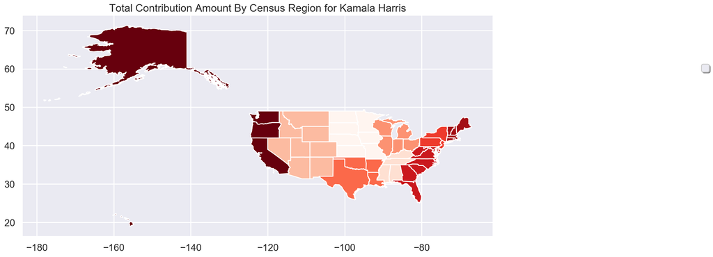

```python
# Add division total to each state for mapping purposes
for i, row in dfBSDivision.iterrows():
    dfBSDivision.at[i,'Division Total'] =  float(dfBSDivision_State.loc[dfBSDivision_State.index == state2division[i]]["contribution_receipt_amount"])
for i, row in dfBODivision.iterrows():
    dfBODivision.at[i,'Division Total'] =  float(dfBODivision_State.loc[dfBODivision_State.index == state2division[i]]["contribution_receipt_amount"])
for i, row in dfKHDivision.iterrows():
    dfKHDivision.at[i,'Division Total'] =  float(dfKHDivision_State.loc[dfKHDivision_State.index == state2division[i]]["contribution_receipt_amount"])

#Drop territories and overseas army data as we are only mapping the 50 states + DC
missing_states = [0, 1, 4, 14, 43, 51, 57]
dfBSDivision = dfBSDivision.drop(dfBSDivision.index[missing_states])
missing_states = [0, 3, 41, 49, 55]
dfBODivision = dfBODivision.drop(dfBODivision.index[missing_states])
missing_states = [0, 40, 48, 54, 55]
dfKHDivision = dfKHDivision.drop(dfKHDivision.index[missing_states])

# Loading shape data for mapping
unitedstates = gpd.read_file('./states_21basic/states.shp')
unitedstates = unitedstates.sort_values(by=['STATE_ABBR'])

# Plot amount raised in each division onto map
iga, ax = plt.subplots(1, 1, figsize=(17, 7))
divider_b = make_axes_locatable(ax)
berniestates = unitedstates.plot(column=dfBSDivision['Division Total'],ax=ax, cmap='Reds')
berniestates.legend(loc='upper center', bbox_to_anchor=(1.45, 0.8), shadow=True, ncol=1)
berniestates.set_title('Total Contribution Amount By Census Region for Bernie Sanders')

iga, ax = plt.subplots(1, 1, figsize=(17, 7))
divider_b = make_axes_locatable(ax)
betostates = unitedstates.plot(column=dfBODivision['Division Total'],ax=ax, cmap='Reds')
betostates.legend(loc='upper center', bbox_to_anchor=(1.45, 0.8), shadow=True, ncol=1)
betostates.set_title('Total Contribution Amount By Census Region for Beto O\'Rourke')

iga, ax = plt.subplots(1, 1, figsize=(17, 7))
divider_b = make_axes_locatable(ax)
kamalastates = unitedstates.plot(column=dfKHDivision['Division Total'],ax=ax, cmap='Reds')
kamalastates.legend(loc='upper center', bbox_to_anchor=(1.45, 0.8), shadow=True, ncol=1)
kamalastates.set_title('Total Contribution Amount By Census Region for Kamala Harris')
```

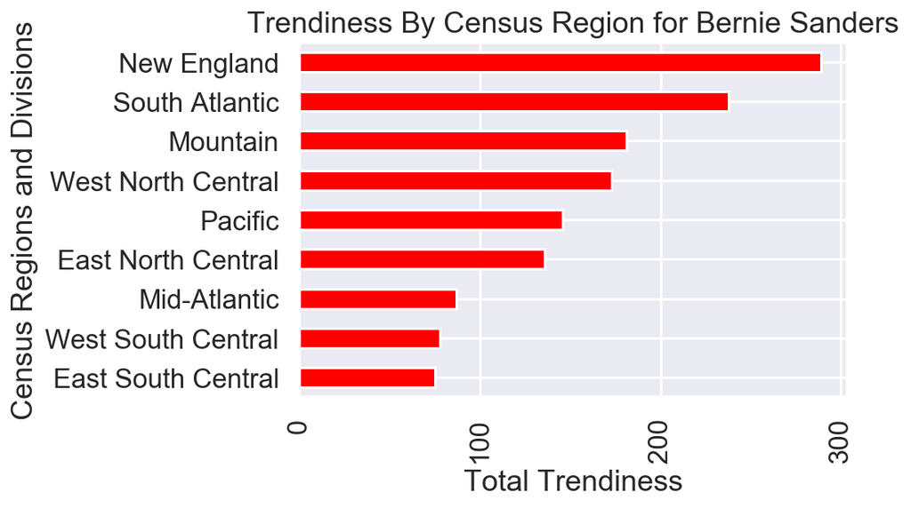

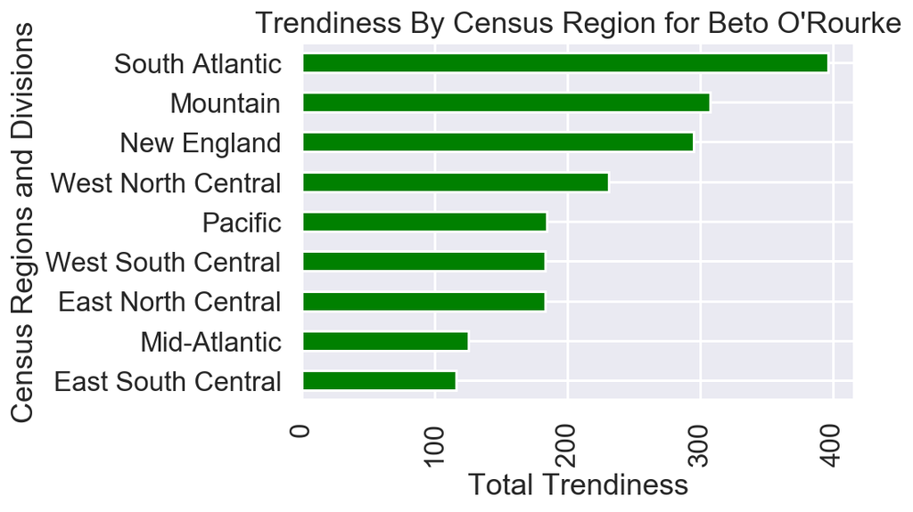

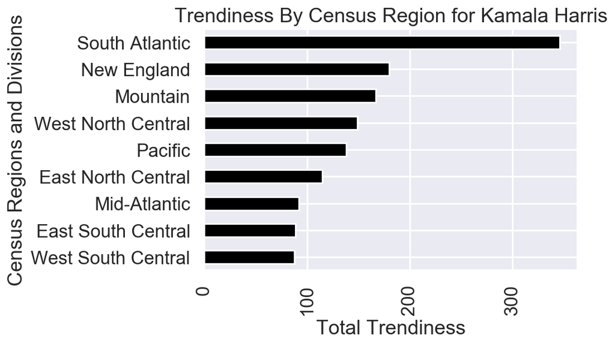

```python
# Census Bureau Division Version
from collections import defaultdict
# Bernie Sanders Fundraising by USCB Division
# Create pivot table to obtain total amount raised by state
# This pivot table is used to aggregate contributions by division
dfBSTrendStates_Division = pd.pivot_table(dfBSTrendStates, index=['state'],values=["trend"],aggfunc=np.sum)
# Set column name
dfBSTrendStates_Division.index.names = ['contributor_state']
dfBSTrendStates_Division['Division'] = ""
dfBSTrendStates_Division['Division Total'] = ""
# Dictionary of state abbreviations with division
state2division = {'AA': 'Territories/Army', 'AE': 'Territories/Army', 'AK': 'Pacific', 'AL': 'East South Central', 'AP': 'Territories/Army', 'AR': 'West South Central', 'AS': 'Territories/Army', 'AZ': 'Mountain', 'CA': 'Pacific', 'CO': 'Mountain', 'CT': 'New England', 'DC': 'South Atlantic', 'DE': 'South Atlantic', 'FL': 'South Atlantic', 'GA': 'South Atlantic', 'GU': 'Territories/Army', 'HI': 'Pacific', 'IA': 'West North Central', 'ID': 'Mountain', 'IL': 'East North Central', 'IN': 'East North Central', 'KS': 'West North Central', 'KY': 'East South Central', 'LA': 'West South Central', 'MA': 'New England', 'MD': 'South Atlantic', 'ME': 'New England', 'MI': 'East North Central', 'MN': 'West North Central', 'MO': 'West North Central', 'MP': 'Territories/Army', 'MS': 'East South Central', 'MT': 'Mountain', 'NC': 'South Atlantic', 'ND': 'West North Central', 'NE': 'West North Central', 'NH': 'New England', 'NJ': 'Mid-Atlantic', 'NM': 'Mountain', 'NV': 'Mountain', 'NY': 'Mid-Atlantic', 'OH': 'East North Central', 'OK': 'West South Central', 'OR': 'Pacific', 'PA': 'Mid-Atlantic', 'PR': 'Territories/Army', 'RI': 'New England', 'SC': 'South Atlantic', 'SD': 'West North Central', 'TN': 'East South Central', 'TX': 'West South Central', 'UT': 'Mountain', 'VA': 'South Atlantic', 'VI': 'Territories/Army', 'VT': 'New England', 'WA': 'Pacific', 'WI': 'East North Central', 'WV': 'South Atlantic', 'WY': 'Mountain', 'ZZ': 'Territories/Army'}
# Add division data to original table
for i, row in dfBSTrendStates_Division.iterrows():
    dfBSTrendStates_Division.at[i,'Division'] = state2division[i]
# Create pivot table to obtain total amount raised in each region
dfBSTrendStates_Division = pd.pivot_table(dfBSTrendStates_Division, index=['Division'],values=["trend"],aggfunc=np.sum)
# Sort pivot table by funds raised from high to low
dfBSTrendStates_Division = dfBSTrendStates_Division.sort_values(by=['trend'])
# Plot ranking of amount raised
f1 = dfBSTrendStates_Division['trend'].plot(kind='barh', color = 'red')
plt.plot()
plt.xticks(rotation = 90)
#f1.get_xaxis().setticks([rotation = 90])
f1.set_xlabel('Total Trendiness')
f1.set_ylabel('Census Regions and Divisions')
f1.set_title('Trendiness By Census Region for Bernie Sanders')
plt.show()

#Beto O'Rourke information
dfBOTrendStates_Division = pd.pivot_table(dfBOTrendStates, index=['state'],values=["trend"],aggfunc=np.sum)
# Set column name
dfBOTrendStates_Division.index.names = ['contributor_state']
dfBOTrendStates_Division['Division'] = ""
dfBOTrendStates_Division['Division Total'] = ""
# Dictionary of state abbreviations with division
state2division = {'AA': 'Territories/Army', 'AE': 'Territories/Army', 'AK': 'Pacific', 'AL': 'East South Central', 'AP': 'Territories/Army', 'AR': 'West South Central', 'AS': 'Territories/Army', 'AZ': 'Mountain', 'CA': 'Pacific', 'CO': 'Mountain', 'CT': 'New England', 'DC': 'South Atlantic', 'DE': 'South Atlantic', 'FL': 'South Atlantic', 'GA': 'South Atlantic', 'GU': 'Territories/Army', 'HI': 'Pacific', 'IA': 'West North Central', 'ID': 'Mountain', 'IL': 'East North Central', 'IN': 'East North Central', 'KS': 'West North Central', 'KY': 'East South Central', 'LA': 'West South Central', 'MA': 'New England', 'MD': 'South Atlantic', 'ME': 'New England', 'MI': 'East North Central', 'MN': 'West North Central', 'MO': 'West North Central', 'MP': 'Territories/Army', 'MS': 'East South Central', 'MT': 'Mountain', 'NC': 'South Atlantic', 'ND': 'West North Central', 'NE': 'West North Central', 'NH': 'New England', 'NJ': 'Mid-Atlantic', 'NM': 'Mountain', 'NV': 'Mountain', 'NY': 'Mid-Atlantic', 'OH': 'East North Central', 'OK': 'West South Central', 'OR': 'Pacific', 'PA': 'Mid-Atlantic', 'PR': 'Territories/Army', 'RI': 'New England', 'SC': 'South Atlantic', 'SD': 'West North Central', 'TN': 'East South Central', 'TX': 'West South Central', 'UT': 'Mountain', 'VA': 'South Atlantic', 'VI': 'Territories/Army', 'VT': 'New England', 'WA': 'Pacific', 'WI': 'East North Central', 'WV': 'South Atlantic', 'WY': 'Mountain', 'ZZ': 'Territories/Army'}
# Add division data to original table
for i, row in dfBOTrendStates_Division.iterrows():
    dfBOTrendStates_Division.at[i,'Division'] = state2division[i]
# Create pivot table to obtain total amount raised in each region
dfBOTrendStates_Division = pd.pivot_table(dfBOTrendStates_Division, index=['Division'],values=["trend"],aggfunc=np.sum)
# Sort pivot table by funds raised from high to low
dfBOTrendStates_Division = dfBOTrendStates_Division.sort_values(by=['trend'])
# Plot ranking of amount raised
f2 = dfBOTrendStates_Division['trend'].plot(kind='barh', color = 'green')
plt.plot()
plt.xticks(rotation = 90)
#f1.get_xaxis().setticks([rotation = 90])
f2.set_xlabel('Total Trendiness')
f2.set_ylabel('Census Regions and Divisions')
f2.set_title('Trendiness By Census Region for Beto O\'Rourke')
plt.show()

#Kamala Harris information
dfKHTrendStates_Division = pd.pivot_table(dfKHTrendStates, index=['state'],values=["trend"],aggfunc=np.sum)
# Set column name
dfKHTrendStates_Division.index.names = ['contributor_state']
dfKHTrendStates_Division['Division'] = ""
dfKHTrendStates_Division['Division Total'] = ""
# Dictionary of state abbreviations with division
state2division = {'AA': 'Territories/Army', 'AE': 'Territories/Army', 'AK': 'Pacific', 'AL': 'East South Central', 'AP': 'Territories/Army', 'AR': 'West South Central', 'AS': 'Territories/Army', 'AZ': 'Mountain', 'CA': 'Pacific', 'CO': 'Mountain', 'CT': 'New England', 'DC': 'South Atlantic', 'DE': 'South Atlantic', 'FL': 'South Atlantic', 'GA': 'South Atlantic', 'GU': 'Territories/Army', 'HI': 'Pacific', 'IA': 'West North Central', 'ID': 'Mountain', 'IL': 'East North Central', 'IN': 'East North Central', 'KS': 'West North Central', 'KY': 'East South Central', 'LA': 'West South Central', 'MA': 'New England', 'MD': 'South Atlantic', 'ME': 'New England', 'MI': 'East North Central', 'MN': 'West North Central', 'MO': 'West North Central', 'MP': 'Territories/Army', 'MS': 'East South Central', 'MT': 'Mountain', 'NC': 'South Atlantic', 'ND': 'West North Central', 'NE': 'West North Central', 'NH': 'New England', 'NJ': 'Mid-Atlantic', 'NM': 'Mountain', 'NV': 'Mountain', 'NY': 'Mid-Atlantic', 'OH': 'East North Central', 'OK': 'West South Central', 'OR': 'Pacific', 'PA': 'Mid-Atlantic', 'PR': 'Territories/Army', 'RI': 'New England', 'SC': 'South Atlantic', 'SD': 'West North Central', 'TN': 'East South Central', 'TX': 'West South Central', 'UT': 'Mountain', 'VA': 'South Atlantic', 'VI': 'Territories/Army', 'VT': 'New England', 'WA': 'Pacific', 'WI': 'East North Central', 'WV': 'South Atlantic', 'WY': 'Mountain', 'ZZ': 'Territories/Army'}
# Add division data to original table
for i, row in dfKHTrendStates_Division.iterrows():
    dfKHTrendStates_Division.at[i,'Division'] = state2division[i]
# Create pivot table to obtain total amount raised in each region
dfKHTrendStates_Division = pd.pivot_table(dfKHTrendStates_Division, index=['Division'],values=["trend"],aggfunc=np.sum)
# Sort pivot table by funds raised from high to low
dfKHTrendStates_Division = dfKHTrendStates_Division.sort_values(by=['trend'])
# Plot ranking of amount raised
f3 = dfKHTrendStates_Division['trend'].plot(kind='barh', color = 'black')
plt.plot()
plt.xticks(rotation = 90)
#f1.get_xaxis().setticks([rotation = 90])
f3.set_xlabel('Total Trendiness')
f3.set_ylabel('Census Regions and Divisions')
f3.set_title('Trendiness By Census Region for Kamala Harris')
plt.show()
```

The graphs above demonstrate the amount of sum of Google Search trend figures by states for each census division for each candidate.  
Bernie Sanders once again leads in New England while O'Rourke and Harris both lead in South Atlantic. It is clear that the top 3 for each candidate are all South Atlantic, New England, and Mountain.

# Data Analysis & Results

### I. Correlation between popularity over time and daily total donation amounts

#### Visualization

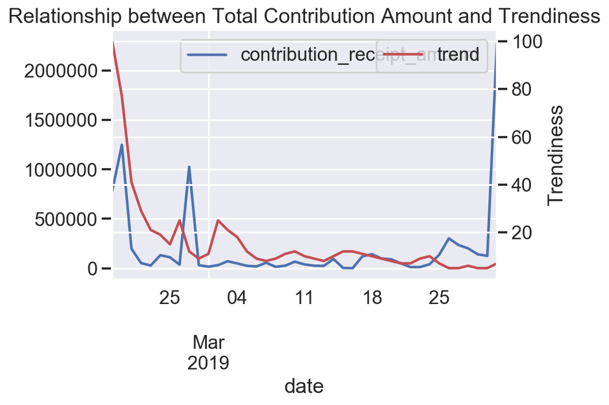

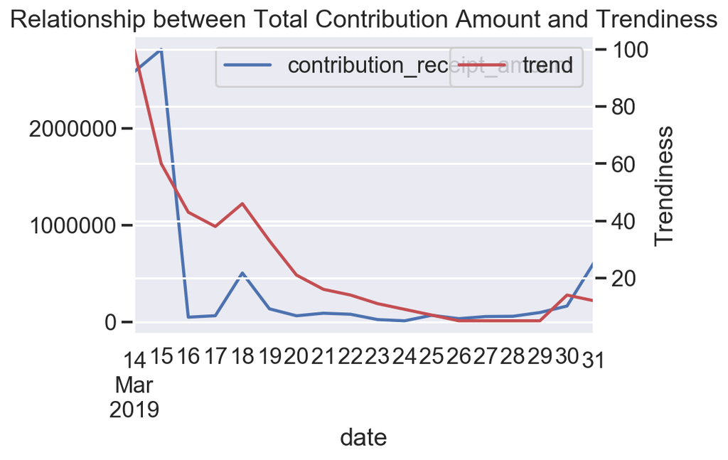

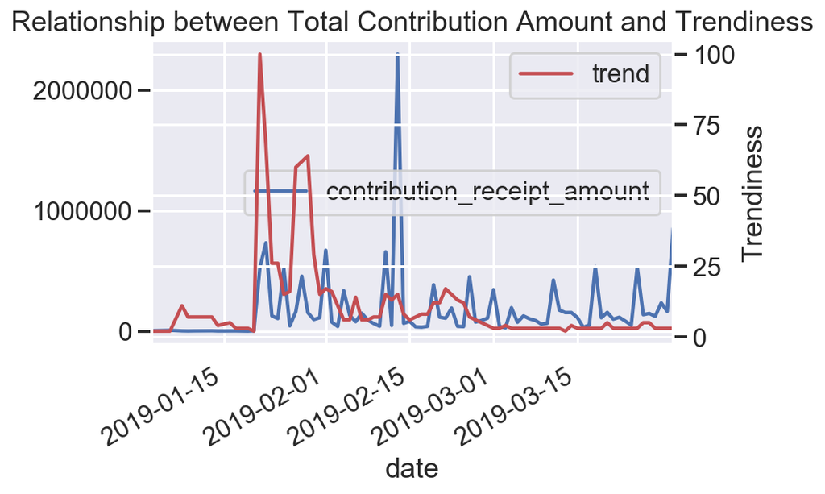

```python
# Bernie Sanders
# Visually analyze correlation between Google Trends figures and total amount raised
# Merge dataframes on date
BSMerged = (pd.merge(dfBSAmount, dfBSTrend, how='outer', on='date'))
# Drop all dates when either fundraising amount was missing or trend data was missing
BSMerged = BSMerged.dropna()
# Plot trends and amount
ax = BSMerged.plot('date','contribution_receipt_amount')
ax1 = ax.twinx()
BernieDiv = BSMerged.plot('date','trend',ax=ax1, color='r')
BernieDiv.set_xlabel('Date')
BernieDiv.set_title('Relationship between Total Contribution Amount and Trendiness')
BernieDiv.set_ylabel('Trendiness')

plt.show()

# Beto O'Rourke
# Visually analyze correlation between Google Trends figures and total amount raised
# Merge dataframes on date
BOMerged = (pd.merge(dfBOAmount, dfBOTrend, how='outer', on='date'))
# Drop all dates when either fundraising amount was missing or trend data was missing
BOMerged = BOMerged.dropna()
# Plot trends and amount
ax = BOMerged.plot('date','contribution_receipt_amount')
ax1 = ax.twinx()
BetoDiv = BOMerged.plot('date','trend',ax=ax1, color='r')
BetoDiv.set_xlabel('Date')
BetoDiv.set_title('Relationship between Total Contribution Amount and Trendiness')
BetoDiv.set_ylabel('Trendiness')


# Kamala Harris
# Visually analyze correlation between Google Trends figures and total amount raised
# Merge dataframes on date
KHMerged = (pd.merge(dfKHAmount, dfKHTrend, how='outer', on='date'))
# Drop all dates when either fundraising amount was missing or trend data was missing
KHMerged = KHMerged.dropna()
# Plot trends and amount
ax = KHMerged.plot('date','contribution_receipt_amount')
ax1 = ax.twinx()
KamalaDiv = KHMerged.plot('date','trend',ax=ax1, color='r')
KamalaDiv.set_xlabel('Date')
KamalaDiv.set_title('Relationship between Total Contribution Amount and Trendiness')
KamalaDiv.set_ylabel('Trendiness')
```

#### Regression analysis between interest over time and daily total contribution amount

```python
# Bernie Sanders
# Analyze correlation between Google Trends figures and total amount raised
# Looking for the correlation between by applying OLS linear regression
outcome_1, predictors_1 = patsy.dmatrices("contribution_receipt_amount~trend", BSMerged)
mod_1 = sm.OLS(outcome_1, predictors_1)
res_1 = mod_1.fit()
print(res_1.summary())
```

```
                                 OLS Regression Results
=======================================================================================
Dep. Variable:     contribution_receipt_amount   R-squared:                       0.114
Model:                                     OLS   Adj. R-squared:                  0.091
Method:                          Least Squares   F-statistic:                     5.022
Date:                         Wed, 12 Jun 2019   Prob (F-statistic):             0.0308
Time:                                 23:03:32   Log-Likelihood:                -586.67
No. Observations:                           41   AIC:                             1177.
Df Residuals:                               39   BIC:                             1181.
Df Model:                                    1
Covariance Type:                     nonrobust
==============================================================================
                 coef    std err          t      P>|t|      [0.025      0.975]
------------------------------------------------------------------------------
Intercept   7.458e+04   8.46e+04      0.881      0.384   -9.66e+04    2.46e+05
trend       7840.7887   3498.827      2.241      0.031     763.744    1.49e+04
==============================================================================
Omnibus:                       70.914   Durbin-Watson:                   1.237
Prob(Omnibus):                  0.000   Jarque-Bera (JB):              775.863
Skew:                           4.277   Prob(JB):                    3.34e-169
Kurtosis:                      22.519   Cond. No.                         32.3
==============================================================================

Warnings:
[1] Standard Errors assume that the covariance matrix of the errors is correctly specified.
```

The result shows that the correlation of the trendiness of Bernie Sanders and the total contribution to Sanders is statistically significant at the p = 0.05 level. This means that, given the null hypothesis is true that no correlation exists between trendiness and total contribution, there is only a 3.1% percent change we would observe this sample. So, for every one unit increase in trendiness, there is an approximately $7,840.78 increase in the total campaign contribution amount.

```python
# Beto O'Rourke
# Analyze correlation between Google Trends figures and total amount raised
# Looking for the correlation between by applying OLS linear regression
outcome_1, predictors_1 = patsy.dmatrices("contribution_receipt_amount~trend", BOMerged)
mod_1 = sm.OLS(outcome_1, predictors_1)
res_1 = mod_1.fit()
print(res_1.summary())
```

```
                                 OLS Regression Results
=======================================================================================
Dep. Variable:     contribution_receipt_amount   R-squared:                       0.642
Model:                                     OLS   Adj. R-squared:                  0.620
Method:                          Least Squares   F-statistic:                     28.72
Date:                         Wed, 12 Jun 2019   Prob (F-statistic):           6.39e-05
Time:                                 23:03:33   Log-Likelihood:                -261.47
No. Observations:                           18   AIC:                             526.9
Df Residuals:                               16   BIC:                             528.7
Df Model:                                    1
Covariance Type:                     nonrobust
==============================================================================
                 coef    std err          t      P>|t|      [0.025      0.975]
------------------------------------------------------------------------------
Intercept  -2.518e+05   1.75e+05     -1.438      0.170   -6.23e+05    1.19e+05
trend       2.703e+04   5043.728      5.359      0.000    1.63e+04    3.77e+04
==============================================================================
Omnibus:                        8.216   Durbin-Watson:                   1.723
Prob(Omnibus):                  0.016   Jarque-Bera (JB):                5.663
Skew:                           0.894   Prob(JB):                       0.0589
Kurtosis:                       5.086   Cond. No.                         49.4
==============================================================================

Warnings:
[1] Standard Errors assume that the covariance matrix of the errors is correctly specified.
```

The result shows that the correlation of the trendiness of Beto O'Rourke and the total contribution to O'Rourke is statistically significant at the p = 0.05 level. In fact, the p-value associated with the trendiness of O'Rourke is 0.000, which means that, if the null hypothesis were true, there would be a 0% chance of observing the correlation. So, for every one unit increase in trendiness, there ia a $27,030 in the total campaign contribution amount, on average.

```python
# Kamala Harris
# Analyze correlation between Google Trends figures and total amount raised
# Looking for the correlation between by applying OLS linear regression
outcome_1, predictors_1 = patsy.dmatrices("contribution_receipt_amount~trend", KHMerged)
mod_1 = sm.OLS(outcome_1, predictors_1)
res_1 = mod_1.fit()
print(res_1.summary())
```

```
                                 OLS Regression Results
=======================================================================================
Dep. Variable:     contribution_receipt_amount   R-squared:                       0.058
Model:                                     OLS   Adj. R-squared:                  0.046
Method:                          Least Squares   F-statistic:                     4.844
Date:                         Wed, 12 Jun 2019   Prob (F-statistic):             0.0307
Time:                                 23:03:33   Log-Likelihood:                -1134.3
No. Observations:                           81   AIC:                             2273.
Df Residuals:                               79   BIC:                             2277.
Df Model:                                    1
Covariance Type:                     nonrobust
==============================================================================
                 coef    std err          t      P>|t|      [0.025      0.975]
------------------------------------------------------------------------------
Intercept   1.384e+05   3.96e+04      3.493      0.001    5.95e+04    2.17e+05
trend       4320.8433   1963.257      2.201      0.031     413.077    8228.609
==============================================================================
Omnibus:                      119.594   Durbin-Watson:                   2.111
Prob(Omnibus):                  0.000   Jarque-Bera (JB):             3421.076
Skew:                           4.863   Prob(JB):                         0.00
Kurtosis:                      33.316   Cond. No.                         24.3
==============================================================================

Warnings:
[1] Standard Errors assume that the covariance matrix of the errors is correctly specified.
```

For Kamala Harris, the correlation between the trendiness and her total campaign contribution amount is also statistically significant, with about the same confidence level as Bernie Sanders. With Kamala Harris, the total campaign contribution amount increases by $4,320.84 for every unit unit increase in trendiness.

### II. Correlation between popularity over time and daily total number of transactions

#### Visualization

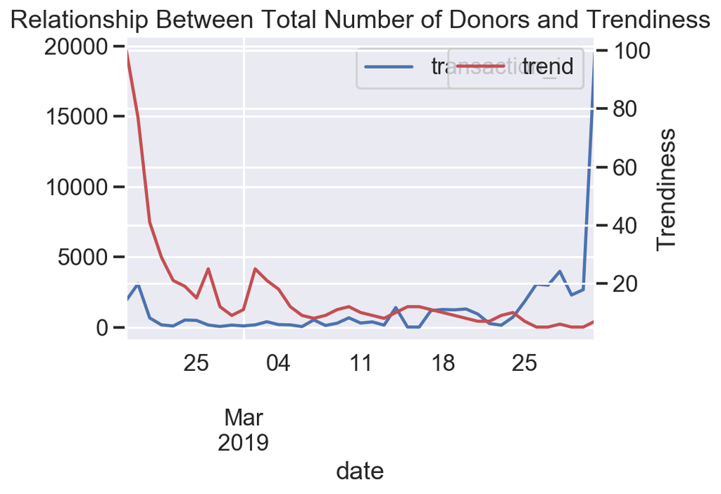

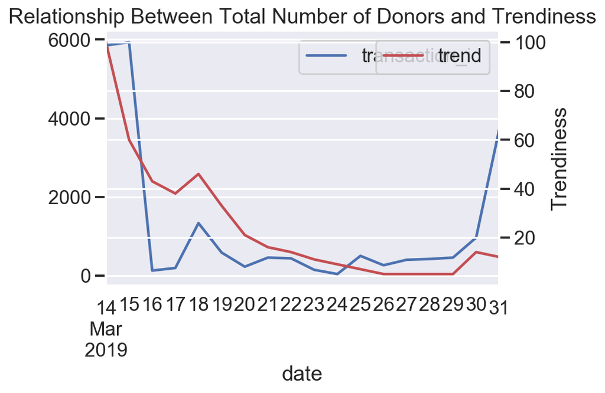

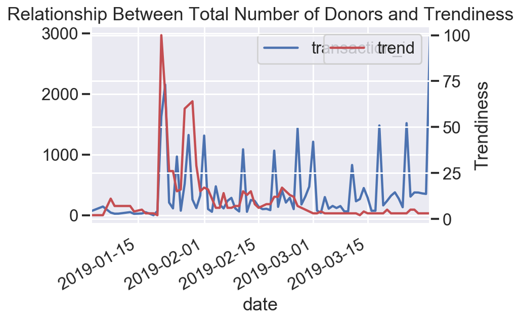

```python
# Bernie Sanders
# Visually analyze correlation between Google Trends figures and total number of transactions each day
# Merge dataframes on date
BSMerged2 = (pd.merge(dfBSDonors, dfBSTrend, how='outer', on='date'))
# Drop all dates when either fundraising amount was missing or trend data was missing
BSMerged2 = BSMerged2.dropna()
# Plot trends and counts
ax = BSMerged2.plot('date','transaction_id')
ax1 = ax.twinx()
BSPopularity = BSMerged2.plot('date','trend',ax=ax1, color='r')
BSPopularity.set_title('Relationship Between Total Number of Donors and Trendiness')
BSPopularity.set_xlabel('Date')
BSPopularity.set_ylabel('Trendiness')


# Beto O'Rourke
# Visually analyze correlation between Google Trends figures and total number of transactions each day
# Merge dataframes on date
BOMerged2 = (pd.merge(dfBODonors, dfBOTrend, how='outer', on='date'))
# Drop all dates when either fundraising amount was missing or trend data was missing
BOMerged2 = BOMerged2.dropna()
# Plot trends and counts
ax = BOMerged2.plot('date','transaction_id')
ax1 = ax.twinx()
BOPopularity = BOMerged2.plot('date','trend',ax=ax1, color='r')
BOPopularity.set_title('Relationship Between Total Number of Donors and Trendiness')
BOPopularity.set_xlabel('Date')
BOPopularity.set_ylabel('Trendiness')


# Kamala Harris
# Visually analyze correlation between Google Trends figures and total number of transactions each day
# Merge dataframes on date
KHMerged2 = (pd.merge(dfKHDonors, dfKHTrend, how='outer', on='date'))
# Drop all dates when either fundraising amount was missing or trend data was missing
KHMerged2 = KHMerged2.dropna()
# Plot trends and counts
ax = KHMerged2.plot('date','transaction_id')
ax1 = ax.twinx()
KOPopularity = KHMerged2.plot('date','trend',ax=ax1, color='r')
KOPopularity.set_title('Relationship Between Total Number of Donors and Trendiness')
KOPopularity.set_xlabel('Date')
KOPopularity.set_ylabel('Trendiness')
```

```python
# Bernie Sanders
# Analyze correlation between Google Trends figures and total number of transactions each day
# Looking for the correlation between by applying OLS linear regression
outcome_1, predictors_1 = patsy.dmatrices("transaction_id~trend", BSMerged2)
mod_1 = sm.OLS(outcome_1, predictors_1)
res_1 = mod_1.fit()
print(res_1.summary())
```

```
                            OLS Regression Results
==============================================================================
Dep. Variable:         transaction_id   R-squared:                       0.001
Model:                            OLS   Adj. R-squared:                 -0.025
Method:                 Least Squares   F-statistic:                   0.02265
Date:                Wed, 12 Jun 2019   Prob (F-statistic):              0.881
Time:                        23:03:39   Log-Likelihood:                -387.36
No. Observations:                  41   AIC:                             778.7
Df Residuals:                      39   BIC:                             782.2
Df Model:                           1
Covariance Type:            nonrobust
==============================================================================
                 coef    std err          t      P>|t|      [0.025      0.975]
------------------------------------------------------------------------------
Intercept   1426.3240    655.198      2.177      0.036     101.061    2751.587
trend         -4.0766     27.089     -0.150      0.881     -58.868      50.715
==============================================================================
Omnibus:                       82.967   Durbin-Watson:                   0.806
Prob(Omnibus):                  0.000   Jarque-Bera (JB):             1494.652
Skew:                           5.152   Prob(JB):                         0.00
Kurtosis:                      30.726   Cond. No.                         32.3
==============================================================================

Warnings:
[1] Standard Errors assume that the covariance matrix of the errors is correctly specified.
```

Based on the OLS Regression Results, the correlation between trendiness and unique donors for Bernie Sanders is not statistically significant. The p-value, .881, is much larger than the expected value of 0.05. Thus, we are forced to reject our null hypothesis that the amount of unique donors increases as a candidate's trendiness rises. In fact, the model indicates that there is a roughly 4-member decrease in unique donors for each unit increase in trendiness. Thus, it is certainly not a positive correlation, or a statistically significant negative correlation for that matter.

```python
# Beto O'Rourke
# Analyze correlation between Google Trends figures and total number of transactions each day
# Looking for the correlation between by applying OLS linear regression
outcome_1, predictors_1 = patsy.dmatrices("transaction_id~trend", BOMerged2)
mod_1 = sm.OLS(outcome_1, predictors_1)
res_1 = mod_1.fit()
print(res_1.summary())
```

```
                            OLS Regression Results
==============================================================================
Dep. Variable:         transaction_id   R-squared:                       0.517
Model:                            OLS   Adj. R-squared:                  0.486
Method:                 Least Squares   F-statistic:                     17.10
Date:                Wed, 12 Jun 2019   Prob (F-statistic):           0.000777
Time:                        23:03:39   Log-Likelihood:                -154.27
No. Observations:                  18   AIC:                             312.5
Df Residuals:                      16   BIC:                             314.3
Df Model:                           1
Covariance Type:            nonrobust
==============================================================================
                 coef    std err          t      P>|t|      [0.025      0.975]
------------------------------------------------------------------------------
Intercept   -103.4215    453.411     -0.228      0.822   -1064.610     857.767
trend         54.0216     13.064      4.135      0.001      26.327      81.716
==============================================================================
Omnibus:                        6.477   Durbin-Watson:                   1.311
Prob(Omnibus):                  0.039   Jarque-Bera (JB):                3.752
Skew:                           0.980   Prob(JB):                        0.153
Kurtosis:                       4.078   Cond. No.                         49.4
==============================================================================

Warnings:
[1] Standard Errors assume that the covariance matrix of the errors is correctly specified.
```

In Beto O'Rourke's case, the correlation is statistically significant. For every unit increase in trendiness, there is a roughly 54 person increase in the number of unique donors O'Rourke receives. This finding is statistically significant at the p = 0.05 level.

```python
# Kamala Harris
# Analyze correlation between Google Trends figures and total number of transactions each day
# Looking for the correlation between by applying OLS linear regression
outcome_1, predictors_1 = patsy.dmatrices("transaction_id~trend", KHMerged2)
mod_1 = sm.OLS(outcome_1, predictors_1)
res_1 = mod_1.fit()
print(res_1.summary())
```

```
                            OLS Regression Results
==============================================================================
Dep. Variable:         transaction_id   R-squared:                       0.136
Model:                            OLS   Adj. R-squared:                  0.125
Method:                 Least Squares   F-statistic:                     12.48
Date:                Wed, 12 Jun 2019   Prob (F-statistic):           0.000690
Time:                        23:03:39   Log-Likelihood:                -616.98
No. Observations:                  81   AIC:                             1238.
Df Residuals:                      79   BIC:                             1243.
Df Model:                           1
Covariance Type:            nonrobust
==============================================================================
                 coef    std err          t      P>|t|      [0.025      0.975]
------------------------------------------------------------------------------
Intercept    257.5300     66.713      3.860      0.000     124.740     390.320
trend         11.6803      3.306      3.533      0.001       5.099      18.261
==============================================================================
Omnibus:                       69.869   Durbin-Watson:                   1.739
Prob(Omnibus):                  0.000   Jarque-Bera (JB):              424.660
Skew:                           2.716   Prob(JB):                     6.11e-93
Kurtosis:                      12.814   Cond. No.                         24.3
==============================================================================

Warnings:
[1] Standard Errors assume that the covariance matrix of the errors is correctly specified.
```

In the case of Kamala Harris, the finding is statistically significant as well, with a roughly 11 person increase in unique donors for every unit increase in trendiness.

### III. Correlation between popularity and total funds raised to-date by state

#### Visualization on trend

```python
# Bernie Sanders
# Visually analyze correlation between Google Trends figures and total amount raised by states
# Merge dataframes on state
BSMerged3 = (pd.merge(dfBSDivision_State, dfBSTrendStates_Division, how='outer', on='Division'))
# Drop all states when either fundraising amount was missing or trend data was missing
BSMerged3 = BSMerged3.dropna()
BSMerged3
```

| Division | contribution_receipt_amount | trend |
| --- | --- | --- |
| East South Central | 3.83e+04 | 75.0 |
| West North Central | 1.03e+05 | 173.0 |
| West South Central | 1.26e+05 | 78.0 |
| Mountain | 1.82e+05 | 181.0 |
| East North Central | 2.93e+05 | 136.0 |
| South Atlantic | 3.55e+05 | 238.0 |
| Mid-Atlantic | 4.31e+05 | 87.0 |
| Pacific | 1.06e+06 | 146.0 |
| New England | 5.58e+06 | 289.0 |

```python
# Beto O'Rourke
# Visually analyze correlation between Google Trends figures and total amount raised by states
# Merge dataframes on state
BOMerged3 = (pd.merge(dfBODivision_State, dfBOTrendStates_Division, how='outer', on='Division'))
# Drop all states when either fundraising amount was missing or trend data was missing
BOMerged3 = BOMerged3.dropna()
BOMerged3
```

| Division | contribution_receipt_amount | trend |
| --- | --- | --- |
| East South Central | 2.95e+04 | 116.0 |
| West North Central | 4.95e+04 | 231.0 |
| East North Central | 1.06e+05 | 183.0 |
| Mountain | 1.32e+05 | 307.0 |
| South Atlantic | 2.93e+05 | 396.0 |
| Mid-Atlantic | 3.67e+05 | 125.0 |
| Pacific | 4.81e+05 | 184.0 |
| West South Central | 2.22e+06 | 183.0 |
| New England | 3.79e+06 | 295.0 |

```python
# Kamala Harris
# Visually analyze correlation between Google Trends figures and total amount raised by states
# Merge dataframes on state
KHMerged3 = (pd.merge(dfKHDivision_State, dfKHTrendStates_Division, how='outer', on='Division'))
# Drop all states when either fundraising amount was missing or trend data was missing
KHMerged3 = KHMerged3.dropna()
KHMerged3
```

| Division | contribution_receipt_amount | trend |
| --- | --- | --- |
| West North Central | 3.87e+04 | 149.0 |
| East South Central | 4.80e+04 | 89.0 |
| Mountain | 1.24e+05 | 167.0 |
| East North Central | 1.77e+05 | 115.0 |
| West South Central | 2.28e+05 | 88.0 |
| Mid-Atlantic | 1.06e+06 | 92.0 |
| South Atlantic | 1.18e+06 | 346.0 |
| New England | 5.54e+06 | 180.0 |
| Pacific | 6.75e+06 | 138.0 |

#### Regression Analysis

```python
# Bernie Sanders
# Analyze correlation between Google Trends figures and total amount raised by Census region
# Looking for the correlation between by applying OLS linear regression
outcome_1, predictors_1 = patsy.dmatrices("contribution_receipt_amount~trend", BSMerged3)
mod_1 = sm.OLS(outcome_1, predictors_1)
res_1 = mod_1.fit()
print(res_1.summary())
```

```
                                 OLS Regression Results
=======================================================================================
Dep. Variable:     contribution_receipt_amount   R-squared:                       0.473
Model:                                     OLS   Adj. R-squared:                  0.398
Method:                          Least Squares   F-statistic:                     6.281
Date:                         Wed, 12 Jun 2019   Prob (F-statistic):             0.0406
Time:                                 23:03:40   Log-Likelihood:                -138.88
No. Observations:                            9   AIC:                             281.8
Df Residuals:                                7   BIC:                             282.1
Df Model:                                    1
Covariance Type:                     nonrobust
==============================================================================
                 coef    std err          t      P>|t|      [0.025      0.975]
------------------------------------------------------------------------------
Intercept  -1.685e+06   1.13e+06     -1.488      0.180   -4.36e+06    9.92e+05
trend       1.663e+04   6635.593      2.506      0.041     939.970    3.23e+04
==============================================================================
Omnibus:                        0.701   Durbin-Watson:                   1.692
Prob(Omnibus):                  0.704   Jarque-Bera (JB):                0.207
Skew:                           0.341   Prob(JB):                        0.902
Kurtosis:                       2.705   Cond. No.                         420.
==============================================================================

Warnings:
[1] Standard Errors assume that the covariance matrix of the errors is correctly specified.
```

In Bernie Sanders' case, the correlation between Google trendiness by region and campaign contribution by region is statistically significant, with a p-value of 0.041. For every one unit increase in trendiness, there is a $16,630 dollar increase in the campaign contribution amount stemming from a Census region.

```python
# Beto O'Rourke
# Analyze correlation between Google Trends figures and total amount raised by Census region
# Looking for the correlation between by applying OLS linear regression
outcome_1, predictors_1 = patsy.dmatrices("contribution_receipt_amount~trend", BOMerged3)
mod_1 = sm.OLS(outcome_1, predictors_1)
res_1 = mod_1.fit()
print(res_1.summary())
```

```
                                 OLS Regression Results
=======================================================================================
Dep. Variable:     contribution_receipt_amount   R-squared:                       0.033
Model:                                     OLS   Adj. R-squared:                 -0.106
Method:                          Least Squares   F-statistic:                    0.2355
Date:                         Wed, 12 Jun 2019   Prob (F-statistic):              0.642
Time:                                 23:03:40   Log-Likelihood:                -138.80
No. Observations:                            9   AIC:                             281.6
Df Residuals:                                7   BIC:                             282.0
Df Model:                                    1
Covariance Type:                     nonrobust
==============================================================================
                 coef    std err          t      P>|t|      [0.025      0.975]
------------------------------------------------------------------------------
Intercept   2.575e+05   1.26e+06      0.204      0.844   -2.73e+06    3.24e+06
trend       2546.4459   5247.269      0.485      0.642   -9861.373     1.5e+04
==============================================================================
Omnibus:                        7.383   Durbin-Watson:                   0.416
Prob(Omnibus):                  0.025   Jarque-Bera (JB):                3.039
Skew:                           1.402   Prob(JB):                        0.219
Kurtosis:                       3.492   Cond. No.                         667.
==============================================================================

Warnings:
[1] Standard Errors assume that the covariance matrix of the errors is correctly specified.
```

```python
# Kamala Harris
# Analyze correlation between Google Trends figures and total amount raised by Census region
# Looking for the correlation between by applying OLS linear regression
outcome_1, predictors_1 = patsy.dmatrices("contribution_receipt_amount~trend", KHMerged3)
mod_1 = sm.OLS(outcome_1, predictors_1)
res_1 = mod_1.fit()
print(res_1.summary())
```

```
                                 OLS Regression Results
=======================================================================================
Dep. Variable:     contribution_receipt_amount   R-squared:                       0.016
Model:                                     OLS   Adj. R-squared:                 -0.125
Method:                          Least Squares   F-statistic:                    0.1129
Date:                         Wed, 12 Jun 2019   Prob (F-statistic):              0.747
Time:                                 23:03:40   Log-Likelihood:                -145.04
No. Observations:                            9   AIC:                             294.1
Df Residuals:                                7   BIC:                             294.5
Df Model:                                    1
Covariance Type:                     nonrobust
==============================================================================
                 coef    std err          t      P>|t|      [0.025      0.975]
------------------------------------------------------------------------------
Intercept   1.069e+06   2.04e+06      0.525      0.616   -3.75e+06    5.89e+06
trend       4038.8488    1.2e+04      0.336      0.747   -2.44e+04    3.25e+04
==============================================================================
Omnibus:                        5.714   Durbin-Watson:                   0.551
Prob(Omnibus):                  0.057   Jarque-Bera (JB):                2.663
Skew:                           1.332   Prob(JB):                        0.264
Kurtosis:                       2.968   Cond. No.                         378.
==============================================================================

Warnings:
[1] Standard Errors assume that the covariance matrix of the errors is correctly specified.
```

In Kamala Harris's case, trendiness per region is also not correlated in a statistically significant way with contribution amount per region, with a very high p-value of 0.747.

# Ethics & Privacy

Our data collection process itself was not affected by ethical dilemmas because both the Census data and campaign contribution amounts were publically available. Our Google trends data is slightly biased in that the popularity rankings given to us per candidate are all relative; the exact number of Google searches per region or per state is not provided to us. Instead, the ranking simply shows us where a candidate experiences hsi highest popularity, and then provides a relative popularity for every other state. For example, since Bernie Sanders has his highest popularity in Vermont, Vermont is given a 100 by Google Trends. The popularity of every other state in terms of search rates is then ranked in comparision, which would indicate that, roughly, for every 100,000 searches a candidate receives in Vermont, he receives 40,000 searches in a state with a ranking of 40. Thus, there is likely a slight skew in how the data is presented. The FEC (Federal Election Commission) data is not subject to this bias because the quantitative values are definitive and accurate.

Another concern of our data collection process is the fact that we confined our study to only three candidates (of the 25) in the 2020 Democratic Primary. As a consequence, any conclusion we derive is corrupted by the fact that the pool of individuals we are deriving conclusions from is rather small. Our selection of our candidates was rooted in (1) those who show the most promise in the 2020 election, (2) those whose campaign contributions were made readily available by the Federal Election Commission. Thus, we were able to avoid any true ethical concerns in our data collection.

# Conclusion & Discussion

Our hypothesis that the total contribution amount, total number of unique donors, and total contribution amount by each state will increase when the candidates’ trendiness rises. Generally, our hypothesis was proven correct, with a few exceptions in certain instances. The total contribution amount is correlated with a candidate's trendiness overtime in a statistically significant manner for all three candidates. So, for all three candidates, we can reject the null hypothesis that the total contribution amount overtime is not correlated with a candidate's trendiness. A limitation in our analysis is that our adjusted R^2 values are inconsistent across each candidate. So, even though we can confirm that we can reject the null hypothesis, we know that the amount of variation of total contribution amount accounted for by the candidate's popularity varies across candidate, which is expected but simultaneously important to consider.

The total number of unique donors was correlated with trendiness overtime for a candidate in a statistically significant manner for Kamala Harris and Beto O'Rourke but not for Bernie Sanders. Thus, in the case of Bernie Sanders, we fail to reject the null hypothesis that a candidate's number of unique donors has no effect on the candidate's popularity overtime. The fact that we are forced to fai to reject our null hypothesis for a candidate points to a limitation in our analysis. We cannot make the sweeping generalization that a correlation exists between trendiness overtime and the number of unique donors overtime, as it does not hold true across all the candidates we choose to analyze.

The correlation between the total contributions for each region and the trendiness of each region was only statistically significant for Bernie Sanders. Thus, of our three alternative hypothesis, the hyptothesis that an increase in trendiness per region will be accompanied by an increase in the total contributions of the region was the weakest.

Overall, we are given some reason to believe that we can reject our null hypothesis, but it is only consistently true for the first case. Thus, perhaps the most relevant takeaway from our project is that, as a candidate's popularity on Google increases, there is likely an increase in their campaign contribution amount as well. In itself, this is a very useful conclusion.